# FigureYa190batchLogistic

# Academic Citation

If you use this code in your work or research, we kindly request that you cite our publication:

Xiaofan Lu, et al. (2025). FigureYa: A Standardized Visualization Framework for Enhancing Biomedical Data Interpretation and Research Efficiency. iMetaMed. https://doi.org/10.1002/imm3.70005

# 需求描述

# Requirement

逻辑回归，这篇文章应该是一个一个做的，我主要想要的是批量。 Logistic regression. This article should be done one by one. What I mainly want is batch production.

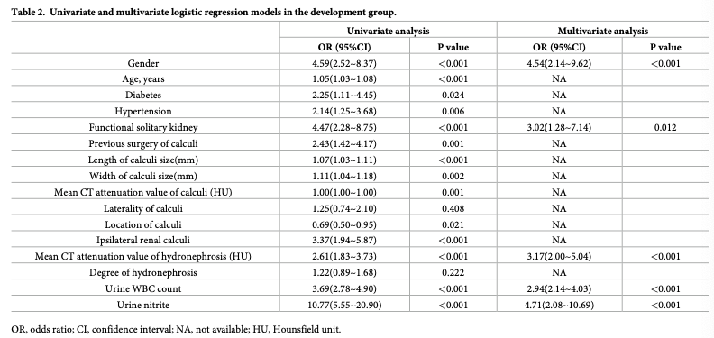

出自https://doi.org/10.1371/journal.pone.0201515 fromhttps://doi.org/10.1371/journal.pone.0201515

# 应用场景

# Application Scenarios

批量计算单变量和多变量逻辑回归。 Batch calculation of univariate and multivariate logistic regression.

这个是逻辑回归，如果要cox回归，可参考FigureYa47HR2table。 This is logistic regression. If you want cox regression, you can refer to Figure A47HR2Table.

# 环境设置

# Environment Setup

```r
source("install_dependencies.R")
```

[output not shown]

```r
library(SimDesign) # 用于沉默逐步回归的信息 # Information for silent stepwise regression

Sys.setenv(LANGUAGE = "en") #显示英文报错信息  # displays an English error message
options(stringsAsFactors = FALSE) #禁止chr转成factor   # prohibit chr from being converted to factor
```

# 输入文件

# Input File

```r
dat <- read.table("easy_input.txt",row.names = 1,sep = "\t",header = T,check.names = F,stringsAsFactors = F)
dat[1:3, 1:3]
```

```
##              MetaStatus  TENM2 SFTPA2
## BLCA-A13J-01          1  0.255  -0.02
## BLCA-A0YR-01          1 -0.185   1.72
## BLCA-A72E-01          1 -0.165  -0.16
```

```r
table(dat$MetaStatus)
```

```
##
##   0   1
## 132  44
```

```r
# 注意，如果变量是基因，一定要把“-”替换成别的符号比如“_”。
# Note that if the variable is a gene, the "-" must be replaced with another symbol, such as "_".
colnames(dat) <- gsub("-","_",colnames(dat))
```

# 循环运算单变量逻辑回归

# Loop operation for univariate logistic regression

```r
rname <- "MetaStatus" #设置响应变量y的变量名  # Set the variable name of the response variable y
vname <- setdiff(colnames(dat), rname) # 设置自变量x的变量名  # sets the variable name of the independent variable x

# 初始化结果向量 # Initialize the result vector
or <- p <- p.lab <- c()
p.cutoff <- 0.05 # 名义p值的阈值   # The threshold of nominal p value
step.dir <- "forward" # 逐步回归的方向，可为backward，forward和both，例文为forward  # The direction of stepwise regression can be backward, forward, or both. The example text is forward

for (v in vname) {
  f <- as.formula(paste0(rname,"~",v)) # 创建公式  # Create Formulas
  t <- dat[,c(rname,v)]

  # 单变量逻辑回归
  # Univariate Logistic regression
  l <- glm(f,
           data = t,
           family = "binomial",
           control = list(maxit = 50),
           na.action = na.exclude)

  s <- format(round(exp(cbind("OR" = coef(l), confint.default(l, level = 0.95)))[2,],3),nsmall = 3) # 调整格式  # Adjust Format
  s <- paste0(s[1]," (",s[2],"-",s[3],")")
  or <- c(or,s) # odd ratio
  p <- c(p,format(round(summary(l)$coefficients[2,4],3),nsmall = 3))
  p.lab <- c(p.lab, # 名义p值的标签  # Nominal P-value label
             ifelse(summary(l)$coefficients[2,4] < 0.001,
                    "<0.001", format(round(summary(l)$coefficients[2,4],3),nsmall = 3)))
}
```

# 多变量回归

# Multivariate regression

```r
# 找出显著变量
# Identify significant variables
vname.sig <- vname[which(as.numeric(p) < p.cutoff)]

if(length(vname.sig) == 0) {
  cat("No significant variable found!\n") # 单变量结果没有显著变量  There are no significant variables in the univariate results
} else if(length(vname.sig) == 1) {
  cat("Only one significant variable found!\n") # 单变量结果只有一个显著变量，不进行多变量回归  The univariate result has only one significant variable and no multivariate regression is conducted
} else {
  cat(paste0("A total of ",length(vname.sig)," significant variables found!\n"))
  f <- as.formula(paste0(rname,"~",paste0(vname.sig,collapse = " + "))) # 创建多变量公式  # Create Multivariate formulas
  t <- dat[,c(rname,vname.sig)]
  l <- glm(f,
           data = t,
           family = "binomial",
           control = list(maxit = 50),
           na.action = na.exclude)
  l.step <- quiet(step(l,direction = step.dir, k = qchisq(p.cutoff/2,1,lower.tail=FALSE))) # 向前支部回归  # Return to the previous branch
  l.step.s <- as.data.frame(format(round(exp(cbind("OR" = coef(l.step),
                                     confint.default(l.step, level = 0.95))),3),nsmall = 3)) # 调整格式  # Adjust Format
  l.step.s$p <- format(round(summary(l.step)$coefficients[,4],3),nsmall = 3)
  l.step.s$p.lab <- ifelse(summary(l.step)$coefficients[,4] < 0.001,
                       "<0.001",format(round(summary(l.step)$coefficients[,4],3),nsmall = 3))

  l.step.s <- l.step.s[setdiff(rownames(l.step.s),"(Intercept)"),] # 移除截距项  # Remove the intercept item
}
```

```
## A total of 21 significant variables found!
```

```r
step.p <- ifelse(l.step.s$p < p.cutoff, l.step.s$p,"")
step.or <- ifelse(step.p == "","NA",paste0(l.step.s$OR," (",l.step.s$`2.5 %`,"-",l.step.s$`97.5 %`,")"))

# 找到在原本显著变量里的位置
# Find the position within the original significant variable
step.p.lab <- rep("", length(vname)); names(step.p.lab) <- vname; step.p.lab[vname.sig] <- step.p
step.or.lab <- rep("NA", length(vname)); names(step.or.lab) <- vname; step.or.lab[vname.sig] <- step.or
```

# 输出表格文件

# Output the table file

## 生成简易表格

## Generate a simple table

```r
outTab <- cbind.data.frame(vname, or, p.lab, step.or.lab, step.p.lab)
colnames(outTab) <- c("","Univariate analysis\nOR (95% CI)","\nP value","Multivariate analysis\nOR (95% CI)","\nP value")
rownames(outTab) <- NULL
write.table(outTab,"batch logistic results.txt",sep = "\t",row.names = F,quote = F)
```

## 输出CSV格式

## Output in CSV format

```r
table_subtitle <- c(NA,"OR (95% CI)","P value","OR (95% CI)","P value")
comtable <- rbind(table_subtitle,outTab,stringsAsFactors = F)
colnames(comtable) <- c("","Univariate analysis","","Multivariate analysis","")
comtable[is.na(comtable)] <- "" #表格里面不打印抬头的NA，但保留“NA”字符串  # Do not print the header "NA" in the table, but keep the "NA" string
str(comtable)
```

```
## 'data.frame':    46 obs. of  5 variables:
##  $                      : chr  "" "TENM2" "SFTPA2" "CES1" ...
##  $ Univariate analysis  : chr  "OR (95% CI)" "0.742 (0.573-0.962)" "1.318 (1.067-1.629)" "1.182 (1.040-1.343)" ...
##  $                      : chr  "P value" "0.024" "0.011" "0.010" ...
##  $ Multivariate analysis: chr  "OR (95% CI)" "NA" "1.458 (1.038-2.048)" "NA" ...
##  $                      : chr  "P value" "" "0.030" "" ...
```

```r
write.csv(comtable,"Table.csv", quote = F, row.names = F)
```

## 输出WORD格式

## Output in WORD format

```r
table_subtitle <- c(NA,"OR (95% CI)","P value","OR (95% CI)","P value")
comtable <- rbind(table_subtitle,outTab,stringsAsFactors = F)
colnames(comtable)<-c(NA,"Univariate analysis",NA,"Multivariate analysis",NA)
comtable[is.na(comtable)] <- "" #表格里面不打印抬头的NA，但保留“NA”字符串  # Do not print the header "NA" in the table, but keep the "NA" string

#保存到word文档
# Save to a word document
title_name<-'Table *. Univariate and multivariate logistic regression'
table1 <- comtable
mynote <- "Note: ..."

if(!require(officer)) (install.packages('officer'))
library(officer)
library(dplyr)
```

```r
my_doc <- read_docx()  #初始化一个docx  # Initialize a docx
my_doc %>%
  ##添加段落标题名称
  ##Add paragraph title names
  body_add_par(value = title_name, style = "table title") %>%

  #添加表格
  #Add Table
  body_add_table(value = table1, style = "Light List Accent 2" ) %>%

  #添加Note
  #Add Note
  body_add_par(value = mynote) %>%

  #打印到word文档
  #Print to word document
  print(target = "Table.docx")
```